# Trait associations, everyone pooled

Which proteins, gene-set scores and module eigengenes follow muscle size and strength when all 16 people are pooled and each trait stays a number? No group label enters any model. Pooling avoids a split, not confounding: a feature that tracks growth may track anything that travels with growth across these people. HR and LR are the top and bottom 8 of 25 by growth, so correlations across them run stronger than they would across all 25.

Four analyses, each for three feature types:

- Sample model. Every T1 and T2 biopsy carries that person’s trait level at that time. Per trait, limma fits feature ~ timepoint + between + within with person as a block. `between` is the person’s mean trait level and `within` the biopsy’s deviation from it. `within` asks whether a feature rises in the biopsies where that person’s trait rose; `between` asks whether people with more of the trait carry more of the feature.
- Change score. One value per person per window, against each trait: limma slope with its 95% interval, Spearman’s rho, and the biweight midcorrelation (bicor, a correlation that down-weights outliers).
- Two predictor: feature ~ growth + strength gain, each slope adjusted for the other. Growth is the composite hypertrophy score; strength gain is the % change in one 1RM.
- Interaction: feature ~ growth × strength gain, asking whether the link to strength gain depends on how much the person grew.

## Packages

```r
library(here)
library(limma)
library(dplyr)
library(tidyr)
library(purrr)
library(ggplot2)
source(here("00_Setup", "Shared_functions", "workbooks.R"))
source(here("00_Setup", "Shared_functions", "person_traits.R"))
inputs <- c(
  corrected = "01_Processing/03_Blood_Correction/c_data/blood_correction.rds",
  singscore = "01_Processing/05_Set_Scores/c_data/set_scores.rds",
  gene_sets = "01_Processing/04_Gene_Sets/c_data/gene_sets.rds",
  modules = "01_Processing/06_Module_Building/c_data/module_building.rds",
  phenotype = "00_Setup/Input/phenotype.csv"
)
paths <- vapply(inputs, here, character(1))
stopifnot(file.exists(paths))
```

## Input

Correlations take no covariate, so proteins come from the blood-corrected matrix; set scores and eigengenes are built on it.

```r
corrected <- readRDS(paths[["corrected"]])
catalog <- filter(readRDS(paths[["gene_sets"]])$set_catalog, qualifies)
modules <- readRDS(paths[["modules"]])
phenotype <- readr::read_csv(paths[["phenotype"]], show_col_types = FALSE)
meta <- as_tibble(corrected$targets)
loaded <- load_features(corrected, readRDS(paths[["singscore"]])$scores, catalog, modules, meta)
features <- loaded$features
label_of <- loaded$label_of
collection_of <- loaded$collection_of
map(features, dim)
```

```
$proteins
[1] 2059   48

$sets
[1] 1422   48

$modules
[1] 10 48
```

## Windows and traits

`trait_windows()` and `window_values()` (from `00_Setup/Shared_functions/person_traits.R`) pair each feature value with its traits. The baseline window asks whether the T1 level predicts the response.

| window | feature value | traits |
| --- | --- | --- |
| `baseline_level` | T1 level | trait levels at T1 |
| `baseline` | T1 level | % change, composite score, volume load |
| `training` | change T1 → T2 | % change, composite score, volume load |
| `post_level` | T2 level | trait levels at T2 |
| `acute` | change T2 → T3 | % change, composite score, volume load |
| `post_bout_level` | T3 level | trait levels at T2 (T3 has no phenotype) |

```r
windows <- trait_windows(phenotype)
trait_of <- map(windows, \(d) setdiff(names(d), "subject"))
trait_value <- \(w, tr, subjects) set_names(windows[[w]][[tr]], windows[[w]]$subject)[subjects]
level_traits <- trait_of$baseline_level
c(screens = sum(lengths(trait_of)))
```

```
screens
     42
```

## Sample model

Per trait, the T1 and T2 biopsies with the trait measured. The within-person correlation is estimated per trait with `duplicateCorrelation()`.

```r
biopsy_traits <- bind_rows(
  T1 = windows$baseline_level, T2 = windows$post_level, .id = "timepoint"
)
sample_model <- function(x, trait) {
  s <- meta |>
    filter(timepoint %in% c("T1", "T2")) |>
    left_join(
      select(biopsy_traits, timepoint, subject, value = all_of(trait)),
      by = c("timepoint", "subject")
    ) |>
    filter(!is.na(value)) |>
    mutate(between = ave(value, subject), within = value - between)
  design <- model.matrix(~ timepoint + between + within, s)
  y <- x[, s$sample_id]
  correlation <- duplicateCorrelation(y, design, block = s$subject)$consensus.correlation
  fit <- eBayes(lmFit(y, design, block = s$subject, correlation = correlation), robust = TRUE)
  map(set_names(c("within", "between")), \(term) {
    topTable(fit, coef = term, number = Inf, sort.by = "none", confint = TRUE) |>
      as_tibble(rownames = "feature") |>
      transmute(
        feature, n_samples = nrow(s), slope = logFC, slope_lower = CI.L, slope_upper = CI.R, t,
        p = P.Value
      )
  }) |>
    list_rbind(names_to = "term")
}
model <- imap(features, \(x, type) {
  map(set_names(level_traits), \(tr) sample_model(x, tr)) |>
    list_rbind(names_to = "trait") |>
    mutate(feature_type = type, .before = 1)
}) |>
  list_rbind()
nrow(model)
```

```
[1] 41892
```

## Change score, two predictor, interaction

`subject_fit()` fits limma on one value per person against the given predictors (robust empirical Bayes) and returns each named term’s slope with its 95% interval, t and p. People missing a predictor drop out. Spearman’s rho and its p (t approximation) come from WGCNA’s `corAndPvalue()`, bicor and its p from `bicorAndPvalue()`.

```r
subject_fit <- function(x, predictors, formula, terms) {
  kept <- complete.cases(predictors)
  fit <- lmFit(x[, kept, drop = FALSE], model.matrix(formula, predictors[kept, , drop = FALSE])) |>
    eBayes(robust = TRUE)
  map(set_names(terms), \(term) {
    topTable(fit, coef = term, number = Inf, sort.by = "none", confint = TRUE) |>
      as_tibble(rownames = "feature") |>
      transmute(
        feature, n_people = sum(kept), slope = logFC, slope_lower = CI.L, slope_upper = CI.R, t,
        p = P.Value
      )
  }) |>
    list_rbind(names_to = "coefficient")
}
change_score_one <- function(x, y) {
  kept <- !is.na(y)
  sp <- WGCNA::corAndPvalue(t(x[, kept]), y[kept], method = "spearman")
  bc <- WGCNA::bicorAndPvalue(t(x[, kept]), y[kept])
  subject_fit(x, data.frame(trait = y), ~trait, "trait") |>
    select(-coefficient) |>
    mutate(rho = sp$cor[, 1], p_rho = sp$p[, 1], bicor = bc$bicor[, 1], p_bicor = bc$p[, 1])
}
per_person <- map(features, \(x) window_values(x, meta))
change_score <- imap(per_person, \(values, type) {
  imap(trait_of, \(traits, w) {
    map(set_names(traits), \(tr) {
      change_score_one(values[[w]], trait_value(w, tr, colnames(values[[w]])))
    }) |>
      list_rbind(names_to = "trait")
  }) |>
    list_rbind(names_to = "window") |>
    mutate(feature_type = type, .before = 1)
}) |>
  list_rbind()
strength_tests <- c("pct_leg_press_1rm", "pct_leg_ext_1rm")
change_windows <- c("baseline", "training", "acute")
two_term <- function(formula, terms) {
  imap(per_person, \(values, type) {
    expand_grid(window = change_windows, strength_test = strength_tests) |>
      mutate(result = map2(window, strength_test, \(w, st) {
        predictors <- data.frame(
          growth = trait_value(w, "comp_hypertrophy", colnames(values[[w]])),
          strength = trait_value(w, st, colnames(values[[w]]))
        )
        subject_fit(values[[w]], predictors, formula, terms)
      })) |>
      unnest(result) |>
      mutate(feature_type = type, .before = 1)
  }) |>
    list_rbind()
}
two_predictor <- two_term(~ growth + strength, c("growth", "strength"))
interaction <- two_term(~ growth * strength, "growth:strength") |>
  select(-coefficient) |>
  rename(interaction = slope, interaction_lower = slope_lower, interaction_upper = slope_upper)
c(change_score = nrow(change_score), two_predictor = nrow(two_predictor),
  interaction = nrow(interaction))
```

```
 change_score two_predictor   interaction
       146622         41892         20946
```

A protein that limpa never observed at a time point gets one estimate for everyone there. It has no spread across people, so its rho and bicor are empty in that window; the limma slope is 0.

```r
filter(change_score, is.na(rho)) |>
  distinct(feature_type, window, feature) |>
  mutate(label = label_of[feature])
```

```
# A tibble: 17 × 4
   feature_type window          feature label
   <chr>        <chr>           <chr>   <chr>
 1 proteins     baseline_level  P31146  CORO1A
 2 proteins     baseline_level  Q15327  ANKRD1
 3 proteins     baseline_level  Q8NE62  CHDH
 4 proteins     baseline        P31146  CORO1A
 5 proteins     baseline        Q15327  ANKRD1
 6 proteins     baseline        Q8NE62  CHDH
 7 proteins     baseline        O15511  ARPC5
 8 proteins     baseline        Q96H20  SNF8
 9 proteins     training        P31146  CORO1A
10 proteins     post_level      P18577  RHCE
11 proteins     post_level      P31146  CORO1A
12 proteins     post_bout_level O00418  EEF2K
13 proteins     post_bout_level P35221  CTNNA1
14 proteins     post_bout_level Q07507  DPT
15 proteins     post_bout_level Q6PGP7  TTC37
16 proteins     post_bout_level Q9NSK7  C19orf12
17 proteins     post_bout_level Q9H488  POFUT1
```

## FDR and counts

`fdr` is Benjamini-Hochberg within one screen: feature type, trait or window and trait (with term, strength test or coefficient where the analysis has them), and collection for sets. At p < 0.05 chance alone puts 5% of features below the line in every screen.

```r
add_fdr <- \(d, ...) {
  d |>
    mutate(
      collection = unname(collection_of[feature]), label = unname(label_of[feature]),
      .after = feature
    ) |>
    mutate(fdr = p.adjust(p, "BH"), .by = c(feature_type, ..., collection))
}
model <- add_fdr(model, trait, term)
change_score <- add_fdr(change_score, window, trait)
two_predictor <- add_fdr(two_predictor, window, strength_test, coefficient)
interaction <- add_fdr(interaction, window, strength_test)
tally <- \(d, analysis, ...) {
  d |>
    summarise(
      n_tested = n(), n_nominal = sum(p < 0.05), n_fdr_05 = sum(fdr < 0.05),
      .by = c(feature_type, ...)
    ) |>
    unite("screen", -c(feature_type, n_tested, n_nominal, n_fdr_05), sep = ", ") |>
    mutate(analysis = analysis, .before = 1)
}
counts <- bind_rows(
  tally(model, "sample model", term, trait),
  tally(change_score, "change score", window, trait),
  tally(two_predictor, "two predictor", window, strength_test, coefficient),
  tally(interaction, "interaction", window, strength_test)
) |>
  mutate(share_nominal = n_nominal / n_tested)
counts |>
  summarise(across(c(n_tested, n_nominal, n_fdr_05), sum), .by = c(analysis, feature_type)) |>
  mutate(share_nominal = round(n_nominal / n_tested, 3))
```

```
# A tibble: 12 × 6
   analysis      feature_type n_tested n_nominal n_fdr_05 share_nominal
   <chr>         <chr>           <int>     <int>    <int>         <dbl>
 1 sample model  proteins        24708      1225        4         0.05
 2 sample model  sets            17064      1103        8         0.065
 3 sample model  modules           120         5        0         0.042
 4 change score  proteins        86478      3682        3         0.043
 5 change score  sets            59724      2930      144         0.049
 6 change score  modules           420        18        0         0.043
 7 two predictor proteins        24708      1302        0         0.053
 8 two predictor sets            17064       921        1         0.054
 9 two predictor modules           120        10        0         0.083
10 interaction   proteins        12354       669        3         0.054
11 interaction   sets             8532       567       46         0.066
12 interaction   modules            60         6        1         0.1
```

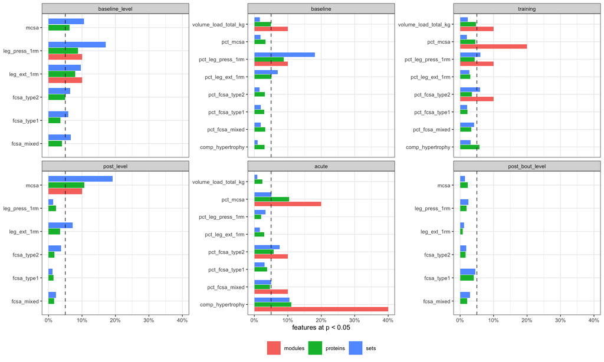

Figure 1: Change score: share of features at limma p < 0.05 per window and trait. Dashed: 5%.

```r
change_score |>
  summarise(share = mean(p < 0.05), .by = c(feature_type, window, trait)) |>
  mutate(window = factor(window, names(windows))) |>
  ggplot(aes(share, trait, fill = feature_type)) +
  geom_col(position = position_dodge(width = 0.8), width = 0.75) +
  geom_vline(xintercept = 0.05, linetype = "dashed", linewidth = 0.3) +
  facet_wrap(~window, nrow = 2, scales = "free_y") +
  scale_x_continuous(labels = scales::label_percent()) +
  labs(x = "features at p < 0.05", y = NULL, fill = NULL) +
  theme_bw(base_size = 8) +
  theme(legend.position = "bottom")
```

The strongest protein links in the training window:

```r
change_score |>
  filter(feature_type == "proteins", window == "training") |>
  slice_min(p, n = 8) |>
  select(trait, label, slope, rho, bicor, p, fdr)
```

```
# A tibble: 8 × 7
  trait                label         slope    rho  bicor        p   fdr
  <chr>                <chr>         <dbl>  <dbl>  <dbl>    <dbl> <dbl>
1 pct_leg_ext_1rm      TMEM126A  0.0838     0.682  0.684 0.000213 0.438
2 pct_leg_press_1rm    TMEM126A -0.0260    -0.824 -0.646 0.000392 0.264
3 pct_leg_press_1rm    SSBP1    -0.0163    -0.679 -0.746 0.000416 0.264
4 pct_leg_press_1rm    ISOC2    -0.0225    -0.559 -0.623 0.000538 0.264
5 pct_leg_press_1rm    HMBS     -0.0290    -0.654 -0.687 0.000624 0.264
6 pct_leg_press_1rm    POTEI    -0.0259    -0.503 -0.555 0.000642 0.264
7 pct_mcsa             MCTS1    -0.0876    -0.829 -0.793 0.000675 0.946
8 volume_load_total_kg ETFRF1   -0.0000160 -0.671 -0.642 0.00124  0.941
```

## Validation

```r
stopifnot(
  nrow(change_score) == sum(map_int(features, nrow)) * sum(lengths(trait_of)),
  all(abs(change_score$rho) <= 1, na.rm = TRUE), all(abs(change_score$bicor) <= 1, na.rm = TRUE),
  sum(is.na(change_score$rho)) < 0.001 * nrow(change_score),
  all(change_score$fdr >= change_score$p), all(model$fdr >= model$p),
  !anyNA(change_score$p), !anyNA(model$p)
)
```

## Summary

```r
totals <- counts |>
  summarise(across(c(n_tested, n_nominal, n_fdr_05), sum), .by = analysis)
totals
```

```
# A tibble: 4 × 4
  analysis      n_tested n_nominal n_fdr_05
  <chr>            <int>     <int>    <int>
1 sample model     41892      2333       12
2 change score    146622      6630      147
3 two predictor    41892      2233        1
4 interaction      20946      1242       50
```

```r
cs <- filter(totals, analysis == "change score")
```

The change score runs 146,622 tests: 6,630 at p < 0.05 against about 7,331 by chance, and 147 at FDR < 0.05.

## Save

`trait_associations.rds` holds the four tables; `02_Trait_Pathways` and `03_Profile_Clusters` read the protein change scores from it.

```r
out <- here("03_Continuous", "01_Trait_Associations", "c_data")
dir.create(out, showWarnings = FALSE)
saveRDS(
  list(
    counts = counts, model = model, change_score = change_score,
    two_predictor = two_predictor, interaction = interaction
  ),
  file.path(out, "trait_associations.rds")
)
write_workbook(
  list(
    counts = counts, model = arrange(model, feature_type, trait, term, collection, p),
    change_score = arrange(change_score, feature_type, window, trait, collection, p),
    two_predictor = arrange(two_predictor, feature_type, window, strength_test, coefficient, p),
    interaction = arrange(interaction, feature_type, window, strength_test, collection, p)
  ),
  c(
    "Tested, p < 0.05 and FDR < 0.05 per analysis, feature type and screen.",
    "Sample model: within and between slopes per trait unit with 95% CI, t, p and FDR.",
    paste(
      "Change score: limma slope with 95% CI, t, p, FDR; Spearman rho and p_rho; bicor and",
      "p_bicor; per feature, window and trait."
    ),
    "Two predictor: growth and strength slopes, each adjusted for the other; 95% CI, t, p, FDR.",
    "Interaction, feature ~ growth x strength gain: interaction with 95% CI, t, p and FDR."
  ),
  file.path(out, "trait_associations.xlsx"), inputs, paths
)
```